# Hands-on 1. Exploratory data analysis and Figure reproduction

Maria Tarrat (mariat.tarrat01@estudiant.upf.edu) Jingqi Fu(jingqi.fu01@estudiant.upf.edu)

Last update: 20 March 2025

# 1. Analysis of the Heart Disease Dataset

Load the data from [here](https://raw.githubusercontent.com/jpinero/DMI_2021/main/datasets/heart_disease_dataset.csv), and the description is [here](https://raw.githubusercontent.com/jpinero/DMI_2021/main/datasets/heart_disease_description.txt). The original dataset comes from [here](https://archive.ics.uci.edu/ml/datasets/Heart+Disease) and corresponds to the [processed cleveland data](https://archive.ics.uci.edu/ml/machine-learning-databases/heart-disease/processed.cleveland.data)

## Perform an EDA on the dataset

```r
# Load all the needed functions for this exercise
library(pacman)


p_load(miceRanger,
       DataExplorer,
       ggplot2,
       outliers,
       dplyr,
       broom,
       ggplot2,
       gridExtra,
       patchwork,
       corrplot)


### Import the data
hd <- read.csv("data/heart_disease_dataset.csv", sep = " ", row.names = "patient_id")
hd <- as.data.frame(hd) # turn it into a data frame
rownames(hd) <- hd$patient_id
head(hd)
```

```
##   age sex cp trestbps chol fbs restecg thalach exang oldpeak slope ca thal num
## 1  63   1  1      145  233   1       2     150     0     2.3     3  0    6   0
## 2  67   1  4      160  286   0       2     108     1     1.5     2  3    3   2
## 3  67   1  4      120  229   0       2     129     1     2.6     2  2    7   1
## 4  37   1  3      130  250   0       0     187     0     3.5     3  0    3   0
## 5  41   0  2      130  204   0       2     172     0     1.4     1  0    3   0
## 6  56   1  2      120  236   0       0     178     0     0.8     1  0    3   0
```

Features of the heart disease dataset (obtained from the description file):

- `age`: age in years
- `sex`: sex (1 = male; 0 = female)
- `cp`: chest pain type [Value 1: typical angina, Value 2: atypical angina, Value 3: non-anginal pain, Value 4: asymptomatic]
- `trestbps`: resting blood pressure (in mm Hg on admission to the hospital)
- `chol`: serum cholestoral in mg/dl
- `fbs`: (fasting blood sugar > 120 mg/dl) (1 = true; 0 = false)
- `restecg`: resting electrocardiographic results [Value 0: normal, Value 1: having ST-T wave abnormality (T wave inversions and/or ST elevation or depression of > 0.05 mV), Value 2: showing probable or definite left ventricular hypertrophy by Estes’ criteria ]
- `thalach`: maximum heart rate achieved
- `exang`: exercise induced angina (1 = yes; 0 = no)
- `oldpeak` = ST depression induced by exercise relative to rest
- `slope`: the slope of the peak exercise ST segment [ Value 1: upsloping, Value 2: flat, Value 3: downsloping]
- `ca`: number of major vessels (0-3) colored by flourosopy
- `thal`: 3 = normal; 6 = fixed defect; 7 = reversable defect
- `num`: diagnosis of heart disease (angiographic disease status) [Value 0: < 50% diameter narrowing, Value 1: > 50% diameter narrowing]

We can divide them into quantitative and categorical featues:

- Quantitative features: age, trestbps, chol, thalach, oldpeak
- Categorical features: sex, cp, fbs, restecg, exang, slope, ca, thal, num

```r
quantitative_features <- c("age", "trestbps", "chol", "thalach", "oldpeak")
categorical_features <- c("sex", "cp", "fbs", "restecg", "exang", "slope", "ca", "thal", "num")

### Data cleaning
## Check the data type
str(hd)
```

```
## 'data.frame':    303 obs. of  14 variables:
##  $ age     : int  63 67 67 37 41 56 62 57 63 53 ...
##  $ sex     : int  1 1 1 1 0 1 0 0 1 1 ...
##  $ cp      : int  1 4 4 3 2 2 4 4 4 4 ...
##  $ trestbps: int  145 160 120 130 130 120 140 120 130 140 ...
##  $ chol    : int  233 286 229 250 204 236 268 354 254 203 ...
##  $ fbs     : int  1 0 0 0 0 0 0 0 0 1 ...
##  $ restecg : int  2 2 2 0 2 0 2 0 2 2 ...
##  $ thalach : int  150 108 129 187 172 178 160 163 147 155 ...
##  $ exang   : int  0 1 1 0 0 0 0 1 0 1 ...
##  $ oldpeak : num  2.3 1.5 2.6 3.5 1.4 0.8 3.6 0.6 1.4 3.1 ...
##  $ slope   : int  3 2 2 3 1 1 3 1 2 3 ...
##  $ ca      : chr  "0" "3" "2" "0" ...
##  $ thal    : chr  "6" "3" "7" "3" ...
##  $ num     : int  0 2 1 0 0 0 3 0 2 1 ...
```

```r
# All of the features are detected as numeric or integers except for ca and thal

## Correct data characters mistakes
# Check if the values in the categorical features are correct
for (feature in categorical_features) {
  print(paste(feature, ":", toString(unique(hd[[feature]]))))
}
```

```
## [1] "sex : 1, 0"
## [1] "cp : 1, 4, 3, 2"
## [1] "fbs : 1, 0"
## [1] "restecg : 2, 0, 1"
## [1] "exang : 0, 1"
## [1] "slope : 3, 2, 1"
## [1] "ca : 0, 3, 2, 1, ?"
## [1] "thal : 6, 3, 7, ?"
## [1] "num : 0, 2, 1, 3, 4"
```

```r
# We have three main issue ca, thal and num values
# We are going to replace the ? and 2,3,4 from num with NA for now
hd$ca[hd$ca == "?"] <- NA
hd$thal[hd$thal == "?"] <- NA
hd$num[hd$num %in% c(2, 3, 4)] <- NA

# Now that the non numeric numbers are gone we can correct the data type for both ca and thal
hd <- type.convert(hd, as.is = TRUE)

# Check if the values in the quantitative features are correct
for (feature in quantitative_features) {
  print(paste(feature, "range:", min(hd[[feature]], na.rm = TRUE), "to", max(hd[[feature]], na.rm = TRUE)))
  # Print summary statistics
  cat("Summary statistics:\n")
  print(summary(hd[[feature]]))
}
```

```
## [1] "age range: 29 to 77"
## Summary statistics:
##    Min. 1st Qu.  Median    Mean 3rd Qu.    Max.
##   29.00   48.00   56.00   54.44   61.00   77.00
## [1] "trestbps range: 94 to 200"
## Summary statistics:
##    Min. 1st Qu.  Median    Mean 3rd Qu.    Max.
##    94.0   120.0   130.0   131.7   140.0   200.0
## [1] "chol range: 126 to 564"
## Summary statistics:
##    Min. 1st Qu.  Median    Mean 3rd Qu.    Max.
##   126.0   211.0   241.0   246.7   275.0   564.0
## [1] "thalach range: 71 to 202"
## Summary statistics:
##    Min. 1st Qu.  Median    Mean 3rd Qu.    Max.
##    71.0   133.5   153.0   149.6   166.0   202.0
## [1] "oldpeak range: 0 to 6.2"
## Summary statistics:
##    Min. 1st Qu.  Median    Mean 3rd Qu.    Max.
##    0.00    0.00    0.80    1.04    1.60    6.20
```

```r
# All the obtained ranges make sense for a heart disease dataset. Some values might seem too high or low for healthy people, but can be possible in patients suffering from heart disease.

## Check for missing values and replace them by imputing
# There are some missing values in our dataset due to us having replaced the incorrect values earlier with NA
colSums(is.na(hd))
```

```
##      age      sex       cp trestbps     chol      fbs  restecg  thalach
##        0        0        0        0        0        0        0        0
##    exang  oldpeak    slope       ca     thal      num
##        0        0        0        4        2       84
```

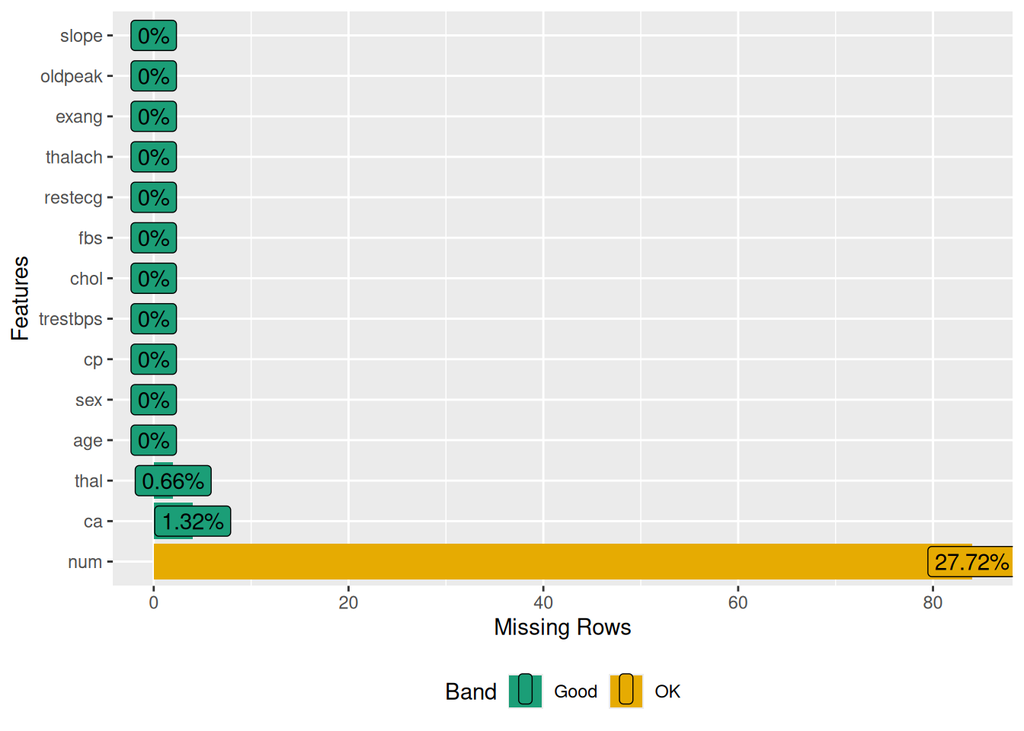

```r
# Plot to visualize the missing data
# The highest percentage of missing values is found in the num feature, which is the heart disease diagnosis. Which can be inferred through imputing if we have all the other features.
missing_plot <- (plot_missing(hd) +
                  theme_minimal() +
                  labs(title = "Percentage of missing data in Heart Disease Dataset",
                       x = "Features",
                       y = "Missing rows") +
                  theme(
                    plot.title = element_text(size = 16, face = "bold"),
                    axis.line = element_line(color = "black"),
                    axis.ticks = element_line(color = "black"),
                    axis.text.x = element_text(angle = 45, hjust = 1, size = 10),
                    panel.grid.minor = element_blank(),
                    legend.position = "bottom"
                  ))
```

```r
# Random seed for reproductibility
set.seed(123)

# Due to the missing values all being in categorical features we use the predictive mean value method for imputing
mice_imputation_pmm <- miceRanger(hd, valueSelector="meanMatch", verbose = FALSE)
# We obtain the first imputed dataset
hd_complete <- completeData(mice_imputation_pmm)[[1]]
hd_complete <- as.data.frame(hd_complete) # hd_complete is a data.table so we convert it to a data frame

# Now we don't have any missing values anymore
colSums(is.na(hd_complete))
```

```
##      age      sex       cp trestbps     chol      fbs  restecg  thalach
##        0        0        0        0        0        0        0        0
##    exang  oldpeak    slope       ca     thal      num
##        0        0        0        0        0        0
```

```r
# We make a list of the variables with missing data and iterate through them to find which values where imputed and by what value
missing_vars <- c("ca", "thal", "num")

for (var in missing_vars) {
  # Get row indices where data was missing
  missing_rows <- which(is.na(hd[[var]]))

  cat("Feature:", var, "\n")
  cat("Rows with missing values:", missing_rows, "\n")
  cat("Imputed values:", hd_complete[missing_rows, var], "\n\n")
}
```

```
## Feature: ca
## Rows with missing values: 167 193 288 303
## Imputed values: 0 1 1 0
##
## Feature: thal
## Rows with missing values: 88 267
## Imputed values: 3 7
##
## Feature: num
## Rows with missing values: 2 7 9 13 24 25 30 32 37 39 41 46 48 53 61 65 66 69 72 80 84 92 97 98 105 107 109 110 114 115 119 120 121 122 124 127 128 137 138 147 154 155 159 162 171 175 181 182 188 190 192 194 196 206 207 208 212 214 224 229 230 232 236 237 244 246 247 249 262 265 266 267 268 273 28…
## Imputed values: 1 1 1 1 0 1 1 1 1 1 1 1 1 0 1 1 1 1 0 1 0 1 1 1 1 1 1 1 1 0 1 1 1 1 1 1 1 1 1 1 1 1 1 1 1 1 1 1 0 0 1 1 1 1 1 1 0 1 1 1 1 1 1 1 0 0 1 1 0 1 1 1 0 1 1 1 1 1 1 0 1 1 1 1
```

```r
## Check for duplicate rows
# There are no duplicates rows
sum(duplicated(hd_complete))
```

```
## [1] 0
```

```r
# Before starting with the plotting we should label the categorical values with their real names
hd_complete$sex <- factor(hd_complete$sex, levels = c(0, 1), labels = c("Female", "Male"))
hd_complete$cp <- factor(hd_complete$cp, levels = c(1, 2, 3, 4),
                labels = c("typical angina", "atypical angina", "non-anginal pain", "asymptomatic"))
hd_complete$fbs <- factor(hd_complete$fbs, levels = c(0, 1), labels = c("False", "True"))
hd_complete$restecg <- factor(hd_complete$restecg, levels = c(0, 1, 2),
                    labels = c("normal", "ST-T wave abnormality", "left ventricular hypertrophy"))
hd_complete$exang <- factor(hd_complete$exang, levels = c(0, 1), labels = c("No", "Yes"))
hd_complete$slope <- factor(hd_complete$slope, levels = c(1, 2, 3), labels = c("upsloping", "flat", "downsloping"))
hd_complete$ca <- factor(hd_complete$ca, levels = c(0, 1, 2, 3),
                labels = c("0 major vessels", "1 major vessel", "2 major vessels", "3 major vessels"))
hd_complete$thal <- factor(hd_complete$thal, levels = c(3, 6, 7),
                  labels = c("normal", "fixed defect", "reversable defect"))

# For simplicity we will interpret the num feature as Disease and No disease
hd_complete$num <- factor(hd_complete$num, levels = c(0, 1),
                 labels = c("No disease", "Disease"))

## Outliers
# We want to find if there are any outliers in the quantitative features

# Obtain feature values that have a z-score higher than 3 (3SD)
for(feature in quantitative_features) {
  feature_values <- hd_complete[[feature]]
  z_scores <- scores(feature_values)

  outlier_threshold <- 3
  outliers_indices <- which(abs(z_scores) > outlier_threshold)

  for (index in outliers_indices){
    cat("Feature =", feature, "\n")
    cat("Outlier =", hd_complete[index, feature], "\n")
    cat("Z-score =", z_scores[index], "\n")
    cat("\n")
  }
}
```

```
## Feature = trestbps
## Outlier = 200
## Z-score = 3.881319
##
## Feature = trestbps
## Outlier = 192
## Z-score = 3.426767
##
## Feature = chol
## Outlier = 417
## Z-score = 3.289244
##
## Feature = chol
## Outlier = 407
## Z-score = 3.096108
##
## Feature = chol
## Outlier = 564
## Z-score = 6.128347
##
## Feature = chol
## Outlier = 409
## Z-score = 3.134735
##
## Feature = thalach
## Outlier = 71
## Z-score = -3.436382
##
## Feature = oldpeak
## Outlier = 6.2
## Z-score = 4.444498
##
## Feature = oldpeak
## Outlier = 5.6
## Z-score = 3.927736
```

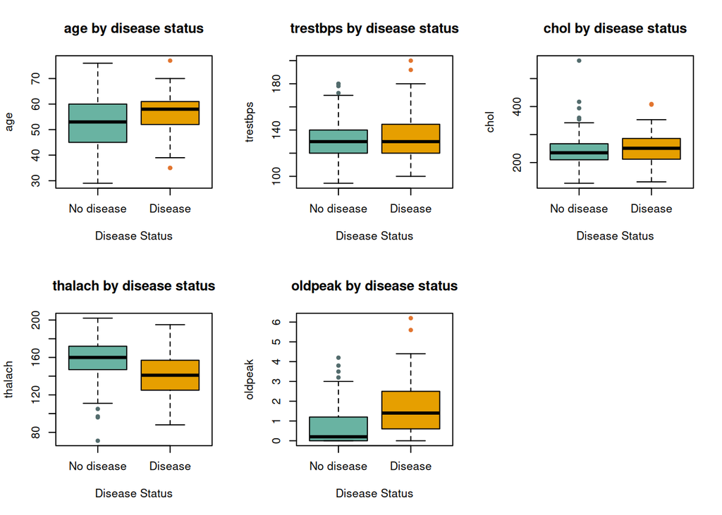

```r
# Here we can see each of the features in a boxplot by disease status, with the outliers highlighted
par(mfrow=c(2,3)) # 2×3 grid for the plots
for(feature in quantitative_features) {
  # Create a boxplot with disease status on x-axis and feature value on y-axis
  boxplot(as.formula(paste(feature, "~ num")),
          data = hd_complete,
          main = paste(feature, "by disease status"),
          xlab = "Disease Status",
          ylab = feature,
          col = c("#69b3a2", "#E69F00"),
          outcol = c("#536c6d", "#e2752f"),
          outpch = 19)
}
```

Due to this being a heart disease dataset it is likely that some of this outliers are real values obtained from a particular patient and taking them out might cause a lose of accuracy.

For this reason we are only be taking out the rows with really extreme outliers, 564 value in chol with a z-score of 6.128347 and the 6.2 value in oldpeak with a z-score of 4.444498. The remaining ones all have an absolute z-score lower than 4.

```r
chol_outlier <- which(hd_complete$chol == 564)
oldpeak_outlier <- which(hd_complete$oldpeak == 6.2)
hd_no_outliers <- hd_complete[-c(chol_outlier, oldpeak_outlier), ]


## Statistics summary
summary(hd_complete)
```

```
##       age            sex                     cp         trestbps
##  Min.   :29.00   Female: 97   typical angina  : 23   Min.   : 94.0
##  1st Qu.:48.00   Male  :206   atypical angina : 50   1st Qu.:120.0
##  Median :56.00                non-anginal pain: 86   Median :130.0
##  Mean   :54.44                asymptomatic    :144   Mean   :131.7
##  3rd Qu.:61.00                                       3rd Qu.:140.0
##  Max.   :77.00                                       Max.   :200.0
##       chol          fbs                              restecg       thalach
##  Min.   :126.0   False:258   normal                      :151   Min.   : 71.0
##  1st Qu.:211.0   True : 45   ST-T wave abnormality       :  4   1st Qu.:133.5
##  Median :241.0               left ventricular hypertrophy:148   Median :153.0
##  Mean   :246.7                                                  Mean   :149.6
##  3rd Qu.:275.0                                                  3rd Qu.:166.0
##  Max.   :564.0                                                  Max.   :202.0
##  exang        oldpeak             slope                   ca
##  No :204   Min.   :0.00   upsloping  :142   0 major vessels:178
##  Yes: 99   1st Qu.:0.00   flat       :140   1 major vessel : 67
##            Median :0.80   downsloping: 21   2 major vessels: 38
##            Mean   :1.04                     3 major vessels: 20
##            3rd Qu.:1.60
##            Max.   :6.20
##                 thal             num
##  normal           :167   No disease:177
##  fixed defect     : 18   Disease   :126
##  reversable defect:118
##
##
##
```

## Create visualizations in order to show which variables seem to be more associated with heart disease

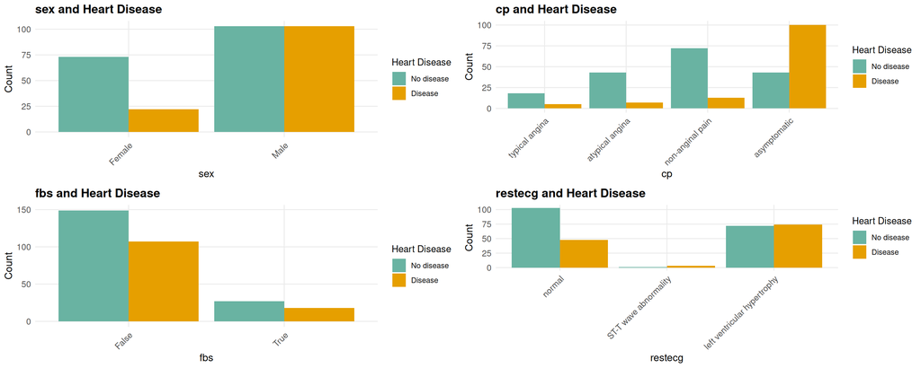

```r
# 1. VISUALIZATION OF VARIABLES
# Create a theme for consistent visualization
my_theme <- theme_minimal() +
  theme(
    plot.title = element_text(size = 14, face = "bold"),
    axis.title = element_text(size = 12),
    axis.text = element_text(size = 10),
    axis.text.x = element_text(angle = 45, hjust = 1),
    legend.position = "right",
    panel.grid.minor = element_blank()
  )

# 1.1 Categorical variables visualization
# Create bar plots for each categorical variable by disease status

# Function to create a bar plot for a categorical variable
create_bar_plot <- function(data, var_name) {
  ggplot(data, aes(x = !!as.name(var_name), fill = num)) +
    geom_bar(position = "dodge") +
    scale_fill_manual(values = c("No disease" = "#69b3a2", "Disease" = "#E69F00")) +
    labs(title = paste(var_name, "and Heart Disease"),
         x = var_name,
         y = "Count",
         fill = "Heart Disease") +
    my_theme
}

# Create a list of plots for categorical variables
cat_plots <- list()
for (var in categorical_features[categorical_features != "num"]) {
  cat_plots[[var]] <- create_bar_plot(hd_no_outliers, var)
}

# Display categorical plots in a grid (4 plots per page)
grid.arrange(grobs = cat_plots[1:4], ncol = 2)
```

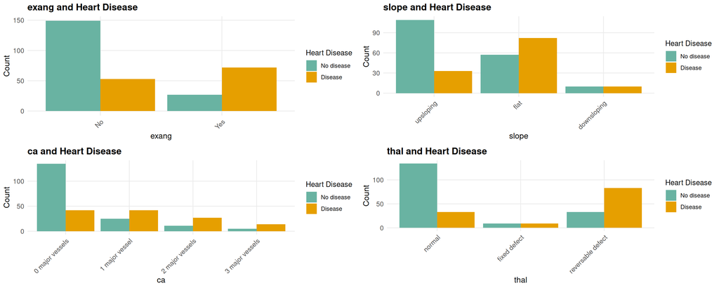

```r
grid.arrange(grobs = cat_plots[5:8], ncol = 2)
```

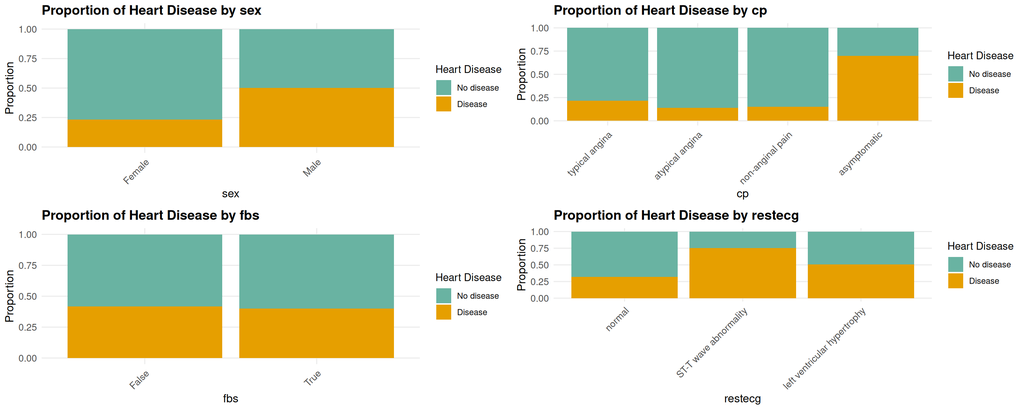

```r
# Alternative view: Proportion of disease by category
# This helps better visualize the relationship
create_prop_plot <- function(data, var_name) {
  # Calculate proportions
  prop_data <- data %>%
    group_by(!!as.name(var_name), num) %>%
    summarise(count = n(), .groups = "drop") %>%
    group_by(!!as.name(var_name)) %>%
    mutate(prop = count / sum(count))

  # Create the plot
  ggplot(prop_data, aes(x = !!as.name(var_name), y = prop, fill = num)) +
    geom_bar(stat = "identity", position = "stack") +
    scale_fill_manual(values = c("No disease" = "#69b3a2", "Disease" = "#E69F00")) +
    labs(title = paste("Proportion of Heart Disease by", var_name),
         x = var_name,
         y = "Proportion",
         fill = "Heart Disease") +
    my_theme
}

# Create proportion plots for categorical variables
prop_plots <- list()
for (var in categorical_features[categorical_features != "num"]) {
  prop_plots[[var]] <- create_prop_plot(hd_no_outliers, var)
}

# Display proportion plots
grid.arrange(grobs = prop_plots[1:4], ncol = 2)
```

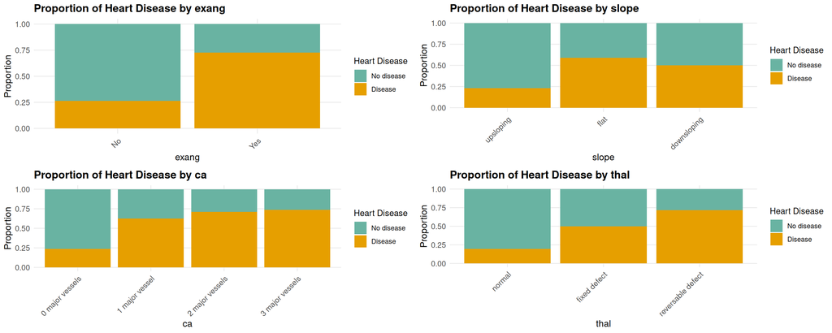

```r
grid.arrange(grobs = prop_plots[5:8], ncol = 2)
```

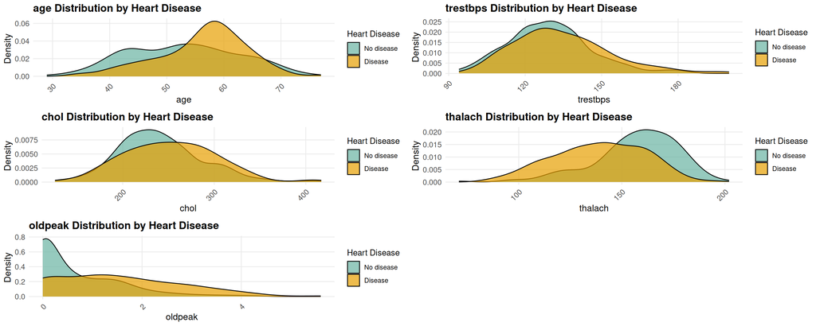

```r
# 1.2 Quantitative variables visualization
# Density plots for quantitative variables by disease status
create_density_plot <- function(data, var_name) {
  ggplot(data, aes(x = !!as.name(var_name), fill = num)) +
    geom_density(alpha = 0.7) +
    scale_fill_manual(values = c("No disease" = "#69b3a2", "Disease" = "#E69F00")) +
    labs(title = paste(var_name, "Distribution by Heart Disease"),
         x = var_name,
         y = "Density",
         fill = "Heart Disease") +
    my_theme
}

# Create density plots
quant_plots <- list()
for (var in quantitative_features) {
  quant_plots[[var]] <- create_density_plot(hd_no_outliers, var)
}

# Display density plots
grid.arrange(grobs = quant_plots, ncol = 2)
```

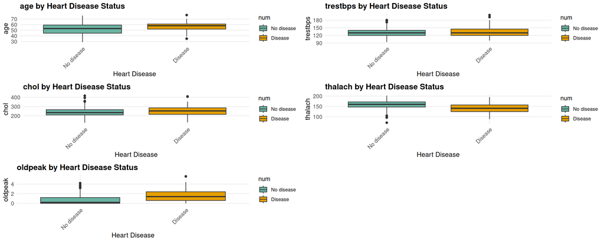

```r
# Boxplots for quantitative variables (alternative view)
create_box_plot <- function(data, var_name) {
  ggplot(data, aes(x = num, y = !!as.name(var_name), fill = num)) +
    geom_boxplot() +
    scale_fill_manual(values = c("No disease" = "#69b3a2", "Disease" = "#E69F00")) +
    labs(title = paste(var_name, "by Heart Disease Status"),
         x = "Heart Disease",
         y = var_name) +
    my_theme
}

# Create boxplots
box_plots <- list()
for (var in quantitative_features) {
  box_plots[[var]] <- create_box_plot(hd_no_outliers, var)
}

# Display boxplots
grid.arrange(grobs = box_plots, ncol = 2)
```

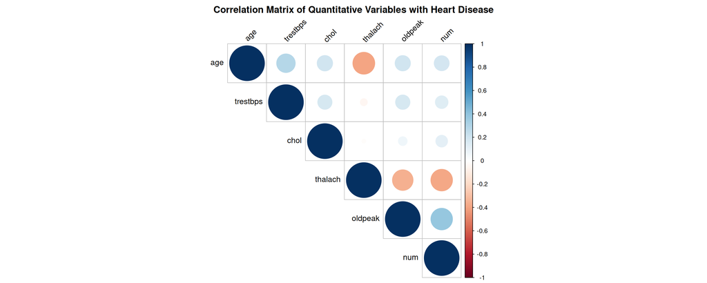

```r
# 2. STATISTICAL ANALYSIS
# 2.1 Correlation analysis for quantitative variables
# Create a numeric dataframe for correlation analysis

numeric_data <- hd_no_outliers %>%
  select(all_of(quantitative_features), num) %>%
  mutate(num = as.numeric(as.character(factor(num, levels = c("No disease", "Disease"), labels = c(0, 1)))))

# Calculate correlation matrix
corr_matrix <- cor(numeric_data)

# Visualization of correlation matrix
corrplot(corr_matrix, method = "circle", type = "upper",
         tl.col = "black", tl.srt = 45,
         title = "Correlation Matrix of Quantitative Variables with Heart Disease",
         mar = c(0, 0, 2, 0))
```

```r
# Calculate individual correlations with heart disease (num)
corr_with_disease <- data.frame(
  variable = quantitative_features,
  correlation = sapply(quantitative_features, function(x) cor(numeric_data[[x]], numeric_data[["num"]]))
)

# Sort by absolute correlation strength
corr_with_disease <- corr_with_disease %>%
  mutate(abs_corr = abs(correlation)) %>%
  arrange(desc(abs_corr))

# Display correlation results
print(corr_with_disease)
```

```
##          variable correlation  abs_corr
## thalach   thalach  -0.3875320 0.3875320
## oldpeak   oldpeak   0.3865404 0.3865404
## age           age   0.1881023 0.1881023
## trestbps trestbps   0.1360200 0.1360200
## chol         chol   0.1171083 0.1171083
```

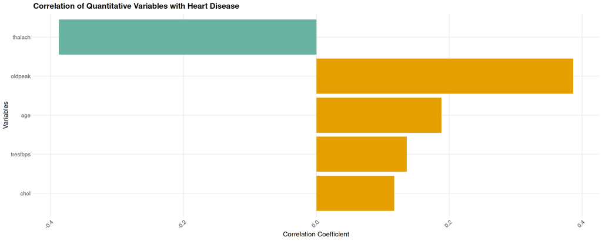

```r
# Visualize correlations with heart disease
ggplot(corr_with_disease, aes(x = reorder(variable, abs_corr), y = correlation)) +
  geom_bar(stat = "identity", fill = ifelse(corr_with_disease$correlation > 0, "#E69F00", "#69b3a2")) +
  coord_flip() +
  labs(title = "Correlation of Quantitative Variables with Heart Disease",
       x = "Variables",
       y = "Correlation Coefficient") +
  my_theme
```

```r
# 2.2 Chi-square test for categorical variables
# Function to perform chi-square test
perform_chi_square <- function(data, var_name) {
  # Create contingency table
  cont_table <- table(data[[var_name]], data[["num"]])

  # Perform chi-square test
  chi_test <- chisq.test(cont_table)

  # Return test results
  return(list(
    variable = var_name,
    p_value = chi_test$p.value,
    chi_squared = chi_test$statistic,
    df = chi_test$parameter
  ))
}

# Perform chi-square test for each categorical variable
chi_results <- lapply(categorical_features[categorical_features != "num"],
                      function(var) perform_chi_square(hd_no_outliers, var))
# Convert results to a data frame
chi_results_df <- do.call(rbind.data.frame, lapply(chi_results, function(x) {
  data.frame(
    variable = x$variable,
    p_value = x$p_value,
    chi_squared = x$chi_squared,
    df = x$df
  )
}))

# Sort by p-value (ascending)
chi_results_df <- chi_results_df %>%
  arrange(p_value)

# Display chi-square results
print(chi_results_df)
```

```
##            variable      p_value  chi_squared df
## X-squared1       cp 1.396859e-19 90.909713611  3
## X-squared7     thal 2.866946e-17 76.181398319  2
## X-squared4    exang 3.865864e-14 57.235717065  1
## X-squared6       ca 2.354439e-12 57.178130080  3
## X-squared5    slope 6.805699e-09 37.611011107  2
## X-squared       sex 1.986705e-05 18.201996054  1
## X-squared3  restecg 1.672903e-03 12.786389231  2
## X-squared2      fbs 9.509024e-01  0.003791301  1
```

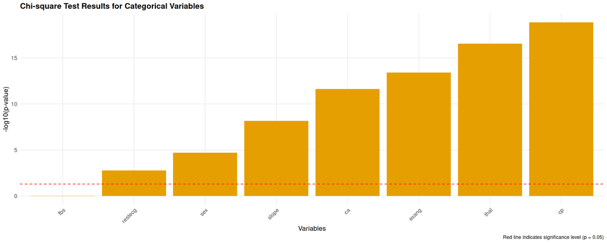

```r
# Visualize chi-square results
ggplot(chi_results_df, aes(x = reorder(variable, -log10(p_value)), y = -log10(p_value))) +
  geom_bar(stat = "identity", fill = "#E69F00") +
  geom_hline(yintercept = -log10(0.05), linetype = "dashed", color = "red") +
  labs(title = "Chi-square Test Results for Categorical Variables",
       x = "Variables",
       y = "-log10(p-value)",
       caption = "Red line indicates significance level (p = 0.05)") +
  my_theme
```

```r
# 3. INFLUENCE ON HEART DISEASE
# Logistic regression to identify important variables

# Prepare data for logistic regression
model_data <- hd_no_outliers
model_data$num_binary <- ifelse(model_data$num == "Disease", 1, 0)

# Convert categorical variables to factors (if not already)
for (var in categorical_features) {
  model_data[[var]] <- as.factor(model_data[[var]])
}

# Fit logistic regression model
log_model <- glm(num_binary ~ age + sex + cp + trestbps + chol + fbs + restecg +
                  thalach + exang + oldpeak + slope + ca + thal,
                data = model_data, family = binomial)

# Summarize model
model_summary <- summary(log_model)
print(model_summary)
```

```
##
## Call:
## glm(formula = num_binary ~ age + sex + cp + trestbps + chol +
##     fbs + restecg + thalach + exang + oldpeak + slope + ca +
##     thal, family = binomial, data = model_data)
##
## Coefficients:
##                                      Estimate Std. Error z value Pr(>|z|)
## (Intercept)                         -6.828646   2.853910  -2.393 0.016723 *
## age                                 -0.020979   0.024528  -0.855 0.392365
## sexMale                              1.293853   0.518437   2.496 0.012572 *
## cpatypical angina                    0.848422   0.824146   1.029 0.303265
## cpnon-anginal pain                   0.176420   0.718181   0.246 0.805955
## cpasymptomatic                       2.405592   0.692977   3.471 0.000518 ***
## trestbps                             0.023887   0.011202   2.132 0.032970 *
## chol                                 0.004269   0.004477   0.954 0.340284
## fbsTrue                             -0.761359   0.556561  -1.368 0.171322
## restecgST-T wave abnormality         1.855609   2.316843   0.801 0.423177
## restecgleft ventricular hypertrophy  0.696217   0.376551   1.849 0.064468 .
## thalach                             -0.009826   0.010598  -0.927 0.353843
## exangYes                             0.720810   0.417325   1.727 0.084129 .
## oldpeak                              0.250032   0.224888   1.112 0.266221
## slopeflat                            0.956235   0.455627   2.099 0.035841 *
## slopedownsloping                     0.531000   0.914046   0.581 0.561285
## ca1 major vessel                     1.873985   0.484083   3.871 0.000108 ***
## ca2 major vessels                    1.993298   0.670938   2.971 0.002969 **
## ca3 major vessels                    1.564389   0.776433   2.015 0.043921 *
## thalfixed defect                    -0.658508   0.777968  -0.846 0.397304
## thalreversable defect                1.279610   0.429787   2.977 0.002908 **
## ---
## Signif. codes:  0 '***' 0.001 '**' 0.01 '*' 0.05 '.' 0.1 ' ' 1
##
## (Dispersion parameter for binomial family taken to be 1)
##
##     Null deviance: 408.59  on 300  degrees of freedom
## Residual deviance: 199.75  on 280  degrees of freedom
## AIC: 241.75
##
## Number of Fisher Scoring iterations: 6
```

```r
# Get tidy model results
tidy_model <- tidy(log_model) %>%
  mutate(
    odds_ratio = exp(estimate),
    lower_ci = exp(estimate - 1.96 * std.error),
    upper_ci = exp(estimate + 1.96 * std.error)
  ) %>%
  filter(term != "(Intercept)") %>%
  arrange(p.value)

# Display model results
print(tidy_model)
```

```
## # A tibble: 20 × 8
##    term        estimate std.error statistic p.value odds_ratio lower_ci upper_ci
##    <chr>          <dbl>     <dbl>     <dbl>   <dbl>      <dbl>    <dbl>    <dbl>
##  1 ca1 major …  1.87      0.484       3.87  1.08e-4      6.51    2.52      16.8
##  2 cpasymptom…  2.41      0.693       3.47  5.18e-4     11.1     2.85      43.1
##  3 thalrevers…  1.28      0.430       2.98  2.91e-3      3.60    1.55       8.35
##  4 ca2 major …  1.99      0.671       2.97  2.97e-3      7.34    1.97      27.3
##  5 sexMale      1.29      0.518       2.50  1.26e-2      3.65    1.32      10.1
##  6 trestbps     0.0239    0.0112      2.13  3.30e-2      1.02    1.00       1.05
##  7 slopeflat    0.956     0.456       2.10  3.58e-2      2.60    1.07       6.36
##  8 ca3 major …  1.56      0.776       2.01  4.39e-2      4.78    1.04      21.9
##  9 restecglef…  0.696     0.377       1.85  6.45e-2      2.01    0.959      4.20
## 10 exangYes     0.721     0.417       1.73  8.41e-2      2.06    0.907      4.66
## 11 fbsTrue     -0.761     0.557      -1.37  1.71e-1      0.467   0.157      1.39
## 12 oldpeak      0.250     0.225       1.11  2.66e-1      1.28    0.826      2.00
## 13 cpatypical…  0.848     0.824       1.03  3.03e-1      2.34    0.464     11.7
## 14 chol         0.00427   0.00448     0.954 3.40e-1      1.00    0.996      1.01
## 15 thalach     -0.00983   0.0106     -0.927 3.54e-1      0.990   0.970      1.01
## 16 age         -0.0210    0.0245     -0.855 3.92e-1      0.979   0.933      1.03
## 17 thalfixed … -0.659     0.778      -0.846 3.97e-1      0.518   0.113      2.38
## 18 restecgST-…  1.86      2.32        0.801 4.23e-1      6.40    0.0682   600.
## 19 slopedowns…  0.531     0.914       0.581 5.61e-1      1.70    0.284     10.2
## 20 cpnon-angi…  0.176     0.718       0.246 8.06e-1      1.19    0.292      4.87
```

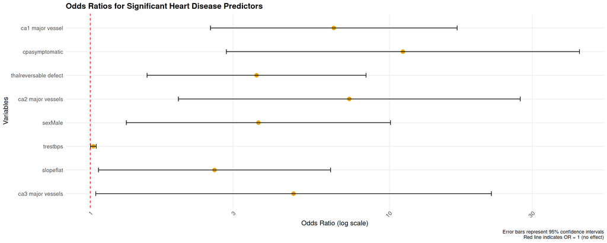

```r
# Visualize top significant predictors
top_predictors <- tidy_model %>%
  filter(p.value < 0.05) %>%
  arrange(p.value)

# Plot odds ratios for significant predictors
ggplot(top_predictors, aes(x = reorder(term, -log10(p.value)), y = odds_ratio)) +
  geom_point(size = 3, color = "#E69F00") +
  geom_errorbar(aes(ymin = lower_ci, ymax = upper_ci), width = 0.2) +
  geom_hline(yintercept = 1, linetype = "dashed", color = "red") +
  coord_flip() +
  labs(title = "Odds Ratios for Significant Heart Disease Predictors",
       x = "Variables",
       y = "Odds Ratio (log scale)",
       caption = "Error bars represent 95% confidence intervals\nRed line indicates OR = 1 (no effect)") +
  scale_y_log10() +
  my_theme
```

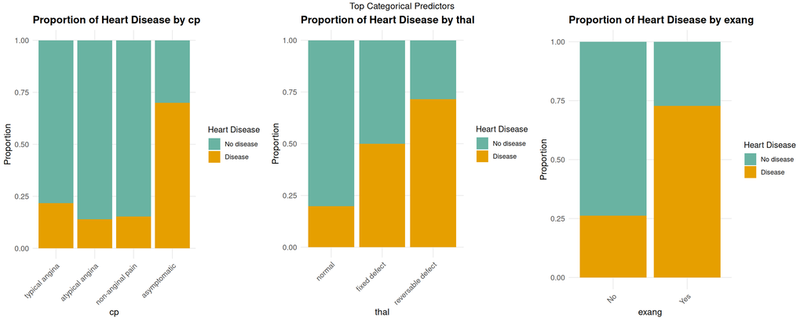

```r
# Create a combined visualization of key findings

# Select top 3 categorical and top 3 quantitative variables based on statistical tests
top_cat_vars <- chi_results_df$variable[1:3]
top_quant_vars <- corr_with_disease$variable[1:3]

# Create plots for top variables
top_cat_plots <- lapply(top_cat_vars, function(var) create_prop_plot(hd_no_outliers, var))
top_quant_plots <- lapply(top_quant_vars, function(var) create_density_plot(hd_no_outliers, var))

# Combine plots
(grid.arrange(grobs = top_cat_plots, ncol = 3, top = "Top Categorical Predictors"))
```

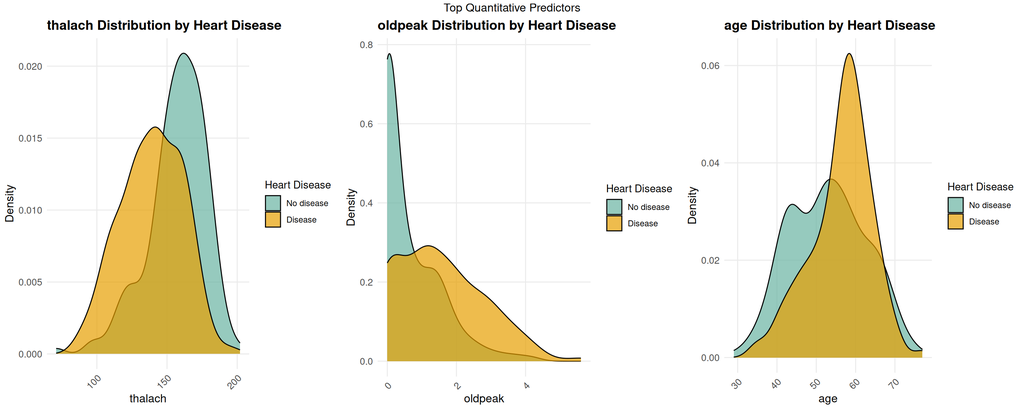

```r
(grid.arrange(grobs = top_quant_plots, ncol = 3, top = "Top Quantitative Predictors"))
```

As for the categorical variables all of them except for fbs show a signinficant association with heart disease. Out of those cp, thal and exang are more significant. Individuals with heart disease are likely to be asymptomatic, have a reversable or fixed defect and to have exercise induced angina.

Additionally males have higher odd of heart disease than females and individuals with heart disease tend to have one or more major vessel.

# 2. Difference in mortality rates in hospitalized COVID-19 patients

Using the supplementary material from the [Difference in mortality rates in hospitalized COVID-19 patients identified by cytokine profile clustering using a machine learning approach: An outcome prediction alternative](https://www.frontiersin.org/articles/10.3389/fmed.2022.987182/full), perform the following tasks

## Reproduce Figure 1 from the publication

```r
# Load all the needed functions for this exercise
p_load(readxl,
       gt,
       dplyr,
       tidyr,
       gridExtra,
       circlize,
       ComplexHeatmap,
       patchwork)

suppressMessages({
  table <- read_excel("data/Figure_1_Table.XLSX")
})
table <- as.data.frame(table) # turn it into a data frame

# Save the first row into variable new_colnames and add the new column names to the table
new_colnames <- as.character(table[1, ])
new_colnames <- gsub(" ", "_", new_colnames)
colnames(table) <- new_colnames
table <- table[-1, ] # delete the first row
rownames(table) <- NULL # resets row numbers
```

First we will start by doing an exploratory data analysis to solve any issues with the data, such as the presence of duplicated IDs or duplicated rows, and decide how to deal with unusual values or typos in the table.

```r
## Exploratory data analysis

#class(table)
#dim(table)
#str(table)

# Find duplicates where the whole row is identical and only keep one of them
duplicates_removed_table <- table[!duplicated(table),]
dim(duplicates_removed_table) # 2 rows removed
```

```
## [1] 212  18
```

```r
# Finds duplicates with the same ID but differences in other values and remove both
incorrect_IDs <- duplicates_removed_table$ID[duplicated(duplicates_removed_table$ID)]
duplicates_and_incorrect_IDs_removed_table <- duplicates_removed_table[!duplicates_removed_table$ID %in% incorrect_IDs, ]
dim(duplicates_and_incorrect_IDs_removed_table) # 12 rows removed
```

```
## [1] 200  18
```

```r
table_modified <- duplicates_and_incorrect_IDs_removed_table

# Replace all NI by NA
for (column_name in new_colnames) {
  for (i in 1:nrow(table_modified)) {
    if (identical(table_modified[[column_name]][i],"NI")) {
      table_modified[[column_name]][i] <- NA
    }
  }
}

# Assign NA to unusual values in the Yes/No columns
Yes_No_column_names <- c("Admission_to_ICU", "ARDS_Diagnosis", "CRS_Diagnosis", "Use_of_NIV", "Use_of_AMV", "Death")

for (column_name in Yes_No_column_names) {
  for (i in 1:nrow(table_modified)) {
    if (!table_modified[[column_name]][i] %in% c("Yes", "No")) {
      table_modified[[column_name]][i] <- NA
    }
  }
}

# Assign NA to unusual values in the Gender column
for (i in 1:nrow(table_modified)) {
  if (!table_modified$Gender[i] %in% c("M", "F")) {
    table_modified$Gender[i] <- NA
  }
}

# Correct typo in some IDs
table_modified$ID <- gsub("HSDJ", "HSJD", table_modified$ID)

# Change , to . in some BMI values
table_modified$BMI <- gsub(",", ".", table_modified$BMI)

# Apply type conversion to all the columns
cleaned_table <- type.convert(table_modified, as.is = TRUE)
str(cleaned_table)
```

```
## 'data.frame':    200 obs. of  18 variables:
##  $ ID                     : chr  "COAG-HSJD-001" "COAG-HSJD-002" "COAG-HSJD-003" "COAG-HSJD-004" ...
##  $ Age                    : int  63 52 74 78 58 58 69 74 51 72 ...
##  $ Gender                 : chr  "F" "M" "M" "M" ...
##  $ BMI                    : num  NA NA 25.8 33.1 NA ...
##  $ Syntoms_onset          : int  44040 44041 NA 44026 44022 44023 44027 44029 44043 44060 ...
##  $ Hospitalization_date   : int  44047 44045 44024 44034 44032 44033 44036 44032 44056 44062 ...
##  $ Admission_to_ICU       : chr  "No" "No" "Yes" "Yes" ...
##  $ Days_in_ICU            : int  0 0 10 13 11 5 19 0 0 6 ...
##  $ ARDS_Diagnosis         : chr  "No" "Yes" "Yes" "Yes" ...
##  $ Days_with_ARDS         : int  0 4 10 19 12 8 26 15 4 6 ...
##  $ CRS_Diagnosis          : chr  "No" "No" "Yes" "Yes" ...
##  $ Days_with_CRS          : int  0 0 10 19 12 0 NA 0 0 6 ...
##  $ Use_of_NIV             : chr  "No" "Yes" "No" "Yes" ...
##  $ Days_with_NIV          : int  0 5 0 6 1 11 13 15 0 0 ...
##  $ Use_of_AMV             : chr  "No" "No" "Yes" "Yes" ...
##  $ Days_with_AMV          : int  0 0 10 13 11 5 13 0 0 6 ...
##  $ Days_of_hospitalization: int  8 5 10 19 12 16 26 25 6 6 ...
##  $ Death                  : chr  "No" "No" "Yes" "Yes" ...
```

```r
# Add a new column with the groups each patient belongs to
for (i in 1:nrow(cleaned_table)) {
  if (is.na(cleaned_table$"Use_of_NIV"[i]) | is.na(cleaned_table$"Use_of_AMV"[i]) | is.na(cleaned_table$"ARDS_Diagnosis"[i])) {
    cleaned_table$Clinical_Classification[i] <- NA
  } else if (cleaned_table$"Use_of_NIV"[i] == "No" & cleaned_table$"Use_of_AMV"[i] == "No" & cleaned_table$"ARDS_Diagnosis"[i] == "No") {cleaned_table$Clinical_Classification[i] <- "G1"
  } else if (cleaned_table$"Use_of_NIV"[i] %in% c("No", "Yes") & cleaned_table$"Use_of_AMV"[i] %in% c("No", "Yes") & cleaned_table$"ARDS_Diagnosis"[i] == "No") {cleaned_table$Clinical_Classification[i] <- "G2"
  } else if (cleaned_table$"Use_of_NIV"[i] == "Yes" & cleaned_table$"Use_of_AMV"[i] == "No" & cleaned_table$"ARDS_Diagnosis"[i] == "Yes") {cleaned_table$Clinical_Classification[i] <- "G3"
  } else if (cleaned_table$"Use_of_NIV"[i] %in% c("No", "Yes") & cleaned_table$"Use_of_AMV"[i] == "Yes" & cleaned_table$"ARDS_Diagnosis"[i] == "Yes") {cleaned_table$Clinical_Classification[i] <- "G4"
  } else {
    cleaned_table$Clinical_Classification[i] <- NA
  }
}

# Create table taking out the rows with NA in the Clinical_Classification column
cleaned_table_without_class_nulls <- cleaned_table %>%
  filter(!is.na(Clinical_Classification))

dim(cleaned_table) # 200 19
```

```
## [1] 200  19
```

```r
dim(cleaned_table_without_class_nulls) # 196 19
```

```
## [1] 196  19
```

```r
# Create table remove rows where Death column has NA values for Figure 4
cleaned_table_no_na_death <- cleaned_table %>%
  filter(!is.na(Death))
```

Now we will reproduce all the images from Figure 1 of the [article](https://www.frontiersin.org/articles/10.3389/fmed.2022.987182/full).

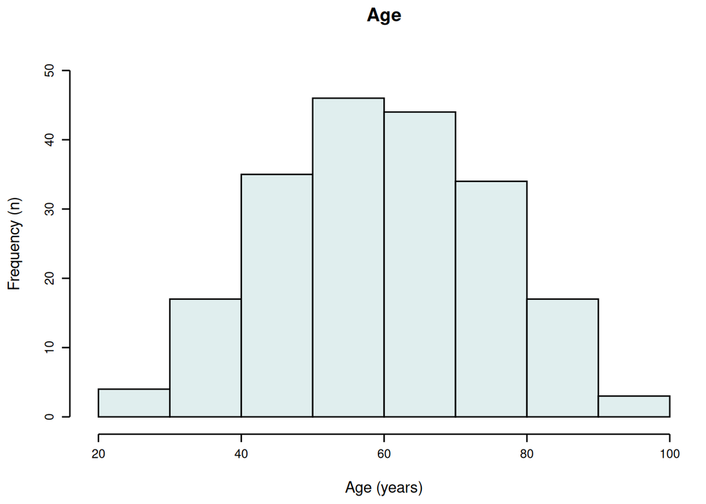

```r
## Figure 1.A
figure1a <- ggplot(data = cleaned_table, mapping = aes(x = Age)) +
            geom_histogram(binwidth = 10, boundary = 20, fill = "#e0eeee", color = "black") +
            theme_minimal() +
            theme(
              axis.line = element_line(color = "black"),
              axis.ticks = element_line(color = "black"),
              axis.ticks.length = unit(0.2, "cm"),
              axis.text = element_text(color = "black"),
              axis.text.x = element_text(margin = margin(t = 5)),
              axis.text.y = element_text(angle = 90, hjust = 0.5, margin = margin(r = 5)),
              axis.title = element_text(color = "black"),
              plot.title = element_text(hjust = 0.5,  face = "bold"),
              panel.grid = element_blank()
            ) +
            labs(x = "\nAge (years)", y = "Frequency (n)\n", title = "Age\n") +
            guides(y = guide_axis(cap = "both"), x = guide_axis(cap = "both")) +
            scale_y_continuous(limits = c(0, 50))
figure1a
```

```r
## Figure 1.B
# Create the classification table
classification_table <- data.frame(
  "Clinical classification" = c("G1", "G2", "G3", "G4"),
  NIV = c("-", "-/+", "+", "-/+"),
  AMV = c("-", "+/-", "-", "+"),
  ARDS = c("-", "-", "+", "+"),
  check.names=FALSE)

figure1b <- classification_table %>%
              gt() %>%
              tab_style(
                style = list(
                  cell_borders(sides = "all", color = "white", weight = px(2)),
                  cell_text(align = "center", color = "black", font = "Arial")
                  ),
                locations = cells_body()
              ) %>%
              tab_style(
                style = list(cell_borders(sides = "all", color = "white", weight = px(2)),
                  cell_text(color = "black", weight = "bold", font = "Arial", align = "center"),
                  cell_fill(color = "#cccccc")),
                locations = cells_column_labels()
              ) %>%
              tab_style(
                style = cell_fill(color = "#f2f2f2"),
                locations = cells_body(rows = c(1, 3))
              ) %>%
              tab_style(
                style = cell_fill(color = "#e5e5e5"),
                locations = cells_body(rows = c(2, 4))
              ) %>%
              tab_style(
                style = "vertical-align:middle",
                locations = cells_column_labels()
              )

figure1b_with_title <-figure1b %>%
                      tab_header(
                        title = md("**Definition of the clinical classification**")
                      )%>%
                      tab_style(
                        style = list(cell_text(color = "#000000", weight = "bold")),
                        locations = cells_title()
                      )

figure1b_with_title
```

**Definition of the clinical classification**

| Clinical classification | NIV | AMV | ARDS |
| --- | --- | --- | --- |
| G1 | - | - | - |
| G2 | -/+ | +/- | - |
| G3 | + | - | + |
| G4 | -/+ | + | + |

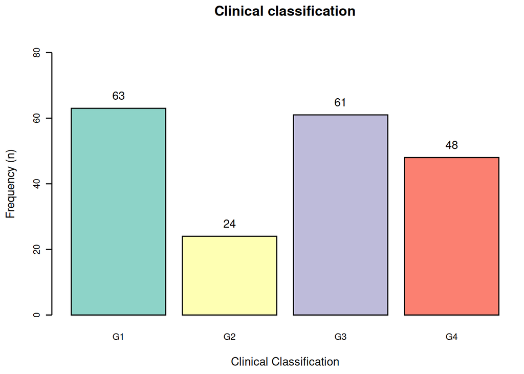

```r
## Figure 1.C
figure1c <- ggplot(data = cleaned_table_without_class_nulls,
                   mapping = aes(x = Clinical_Classification, fill = Clinical_Classification)) +
            geom_bar(color = "black", width = 0.85) +
            scale_fill_manual(values = c("#8dd3c8","#feffb3", "#bebbda", "#fb8071")) +
            geom_text(stat = "count", aes(label = after_stat(count)), vjust = -1, color = "black") +
            theme_minimal() +
            theme(
              axis.line.y = element_line(color = "black"),
              axis.text.y = element_text(angle = 90, hjust = 0.5, margin = margin(r = 5)),
              axis.text = element_text(color = "black"),
              axis.ticks.y = element_line(color = "black"),
              axis.ticks.length.y = unit(0.2, "cm"),
              panel.grid = element_blank(),
              plot.title = element_text(hjust = 0.5,  face = "bold"),
              legend.position = "none"
              ) +
            labs(x = "\nClinical Classification",
                 y = "Frequency (n)\n",
                 title = "Clinical classification\n") +
            guides(y = guide_axis(cap = "both")) +
            scale_y_continuous(limits = c(0, 80))
figure1c
```

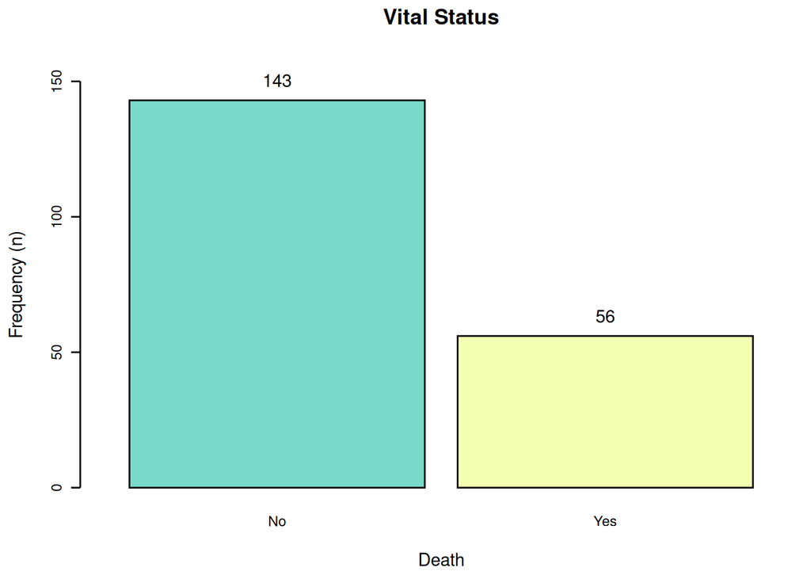

```r
## Figure 1.D

# Create the bar plot
figure1d <- ggplot(data = cleaned_table_no_na_death, mapping = aes(x = Death, fill = Death)) +
              geom_bar(color = "black") + # Create bar chart with black borders, fill is based on 'Death'
              geom_text(stat = "count", aes(label = after_stat(count)), vjust = -1, color = "black") +  # Add frequency labels on top of bars
              theme_minimal() +  # Apply minimal theme
              theme(
                axis.line.y = element_line(color = "black"),  # Add black axis line on y-axis
                axis.text.y = element_text(angle = 90, hjust = 0.5, margin = margin(r = 5)),  # Rotate y-axis text for better readability
                axis.text = element_text(color = "black"),  # Set axis text color to black
                axis.ticks.y = element_line(color = "black"),  # Add black ticks to y-axis
                axis.ticks.length.y = unit(0.2, "cm"),  # Customize y-axis tick length
                panel.grid = element_blank(),  # Remove grid lines
                plot.title = element_text(hjust = 0.5, face = "bold"),  # Center and bold the plot title
                legend.position = "none"
              ) +
              labs(
                x = "\nDeath",  # Label for x-axis
                y = "Frequency (n)\n",  # Label for y-axis
                title = "Vital Status\n"  # Title of the plot
              ) +
              guides(y = guide_axis(cap = "both")) +  # Add caps to the y-axis labels
              scale_y_continuous(limits = c(0, 150)) +  # Set y-axis limits (adjust according to data)
              scale_fill_manual(values = c("No" = "#79dac9", "Yes" = "#f3ffb1"))  # Manually assign colors: green for 'No', yellow for 'Yes'
figure1d
```

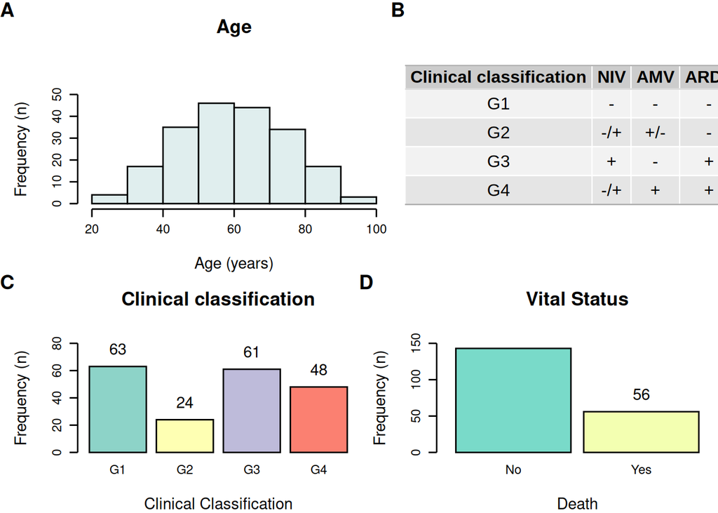

```r
# Arrange all the figures in a 2x2 grid and display Figure 1
combined_figure <- (figure1a | figure1b) / (figure1c | figure1d) +
  plot_annotation(
    tag_levels = 'A',
  ) &
  theme(plot.margin = margin(0, 0, 0, 0),
        plot.tag = element_text(face = "bold", size = 14) )

combined_figure
```

## Reproduce Figure 2 from the publication

But instead of representing the clusters in the annotation, represent the groups (G1 to G4)

First we started by doing an overview of the data, correcting typos, checking for duplicated or strange values and removing rows where all the data is NA.

```r
suppressMessages({
  table_2 <- read_excel("data/Figure_2_Table.XLSX")
})
table_2 <- as.data.frame(table_2)

# Save first row names as column names and add the new column names to the table
new_colnames_2 <- as.character(table_2[1, ])
new_colnames_2 <- gsub(" ", "_", new_colnames_2)
colnames(table_2) <- new_colnames_2
colnames(table_2)[1] <- "ID"
table_2 <- table_2[-1, ] # delete the first row
rownames(table_2) <- NULL # resets row numbers


# Fill the the empty spaces in the ID column with the ID belonging to the closest existing ID
table_2 <- table_2 %>%
  fill(ID, .direction = "down")

# Check for duplicates
any(duplicated(table_2)) # There are no duplicates
```

```
## [1] FALSE
```

```r
# Replace all NI by NA
for (column_name in new_colnames_2) {
  for (i in 1:nrow(table_2)) {
    if (identical(table_2[[column_name]][i],"NI")) {
      table_2[[column_name]][i] <- NA
    }
  }
}

# Replace all ND (not detected) by 0
for (i in 1:nrow(table_2)) {
  if (identical(table_2$`IL-6`[i],"ND")) {
    table_2$`IL-6`[i] <- 0
  }
}

# Correct typo in some IDs
table_2$ID <- gsub("HSDJ", "HSJD", table_2$ID)

# Obtain the columns we are interested in and apply type conversion to the table
table_2_filtered_col <- table_2[, c(1:14)]
table_2_filtered_col <- type.convert(table_2_filtered_col, as.is = TRUE)
str(table_2_filtered_col)
```

```
## 'data.frame':    445 obs. of  14 variables:
##  $ ID    : chr  "COAG-HSJD-001" "COAG-HSJD-002" "COAG-HSJD-003" "COAG-HSJD-003" ...
##  $ Day   : int  1 1 1 3 5 7 9 11 1 1 ...
##  $ IL-1β : num  0 0 0 0 NA NA NA NA 0 0 ...
##  $ IL-6  : num  4.6 0.5 147.7 169.5 NA ...
##  $ IL-10 : num  4.06 9.16 4.7 0 NA NA NA NA 4.8 7.35 ...
##  $ IFN-ɑ : num  2.69 2.52 0.4 2.28 NA ...
##  $ TNF-ɑ : num  0.72 1.4 0 1.4 NA ...
##  $ IL-8  : num  37.62 8.66 133.53 96.71 NA ...
##  $ G-CSF : num  3.7 2.52 10.34 13.04 NA ...
##  $ IFN-γ : num  4.68 3.72 3.64 4.09 NA ...
##  $ CCL3  : num  4.07 5.07 20.07 5.98 NA ...
##  $ CXCL10: num  2388 1490 2136 1026 NA ...
##  $ CCL2  : num  58.9 13.7 901.5 263.4 NA ...
##  $ IL-38 : num  567 655 888 952 NA ...
```

```r
# Filter out the rows were all the data is NA
table_2_filtered_col_rows <- table_2_filtered_col %>% filter(!if_all(-c("ID","Day"), ~ is.na(.)))
```

Here we calculated the median value per cytokine per patient and merged the table with the main table from exercise 1. Afterwards, all the necessary preparations and normalization of the data for the heatmap were done.

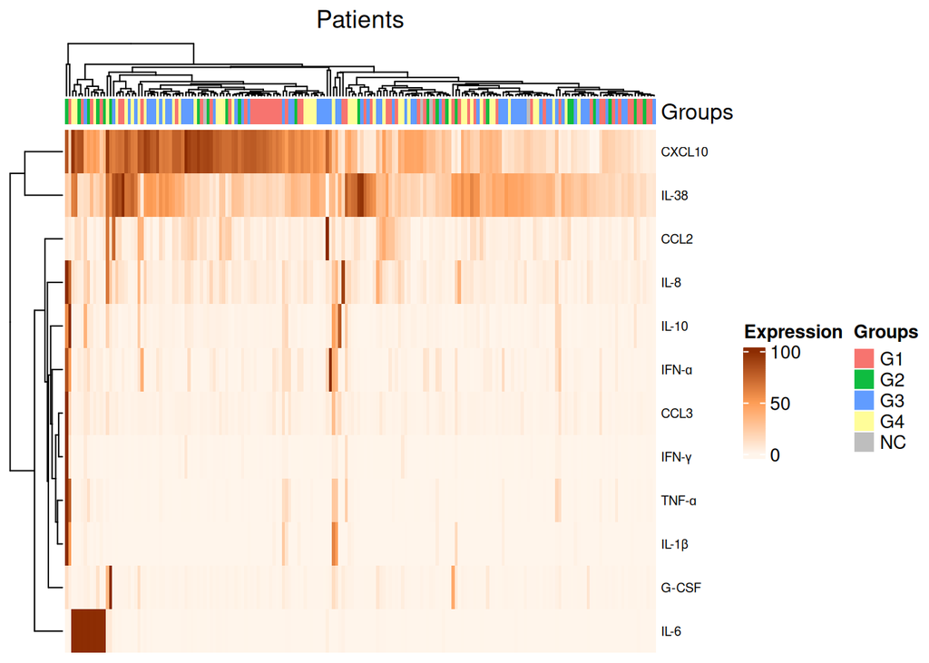

```r
# Calculate the median value of each cytokine per patient across the multiple days (similar to what the article does)
table_2_with_medians <- table_2_filtered_col_rows %>%
  group_by(ID) %>%                                            # Group by the ID
  summarise(across(where(is.numeric), \(x) median(x, na.rm = TRUE)))  # Apply median function in
                                                                      # numeric columns

# Select only the ID, Classification, Gender and Death columns from the main table of exercise 2 part 1
classification_table <- cleaned_table[] %>%
  select(ID, Clinical_Classification, Gender, Death)

# Merge with the main data table from exercise 1 part 1 (so we will only use the IDs which were not duplicated)
merged_table <- left_join(classification_table, table_2_with_medians, by = "ID")
# Filter out rows where the ID is found in the main table but no cytokine data is found
merged_table <- merged_table %>% filter(!if_all(-c("ID", "Clinical_Classification", "Gender", "Death", "Day"), ~ is.na(.)))

# Clinical classification, Gender and Death columns are stored in groups.
group_labels <- as.character(merged_table[[2]])
gender_labels <- as.character(merged_table[[3]])
death_labels <- as.character(merged_table[[4]])
# Samples that don't have a classification are named NC for not classified
group_labels[is.na(group_labels)] <- "NC"
gender_labels[is.na(gender_labels)] <- "NC"
death_labels[is.na(death_labels)] <- "NC"


# The clinical ID, Day, Clinical classification, Gender and Death columns are taken out are taken out to create a numerical table
merged_table_numerical <- merged_table %>%
  select(-ID, -Day, -Clinical_Classification, -Gender, -Death)

# Normalize the table with the Min-Max Normalization method
normalize <- function(x) {
  return((x - min(x, na.rm = TRUE)) / (max(x, na.rm = TRUE) - min(x, na.rm = TRUE)) * 100)
}

normalized_table <- apply(merged_table_numerical, 2, normalize)

# Create the colors palette needed for the annotation
groups_palette <- c("#f7746f", "#0fbc40", "#619cff", "#fffd99", "grey")
colors_by_group <- groups_palette[as.factor(group_labels)]



# Heatmap
column_annotations = HeatmapAnnotation(
  Groups = group_labels,
  col = list(
    Groups = setNames(unique(colors_by_group), unique(group_labels))
  ),
  show_legend = TRUE
)

normalized_table_t <- t(normalized_table)

# We add a supress warnings to avoid the conversion failure warning of the unusual characters. As the final result has these characters correctly displayed it is not a problem
suppressWarnings(
  Heatmap(normalized_table_t,
          name = "Expression",
          col = colorRamp2(c(0, 50, 100),
                         c("#fff5eb", "#fd9c55", "#8c2c02")),
          top_annotation = column_annotations,
          show_row_names = TRUE,
          show_column_names = FALSE,
          row_names_gp = gpar(fontsize = 7),
          column_title = "Patients")
)
```

## Improve figure 2 of the publication

Add a second annotation with information of deathm and a third one with information of gender

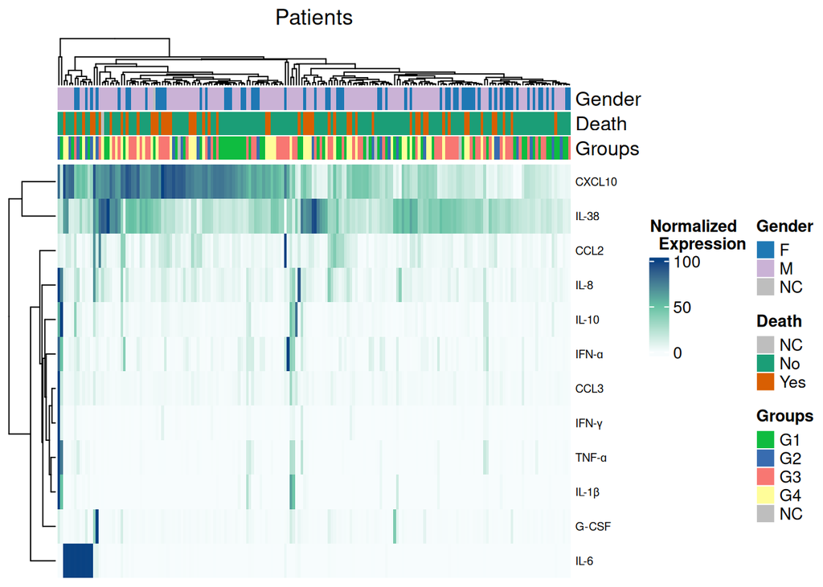

```r
# Create all the colors palettes needed for all the annotations
groups_palette <- c("#0fbc40", "#386cb0", "#f87772", "#fffd99", "grey")
colors_by_group <- groups_palette[as.factor(group_labels)]
gender_palette <- c("#1f78b4", "#cab2d6", "grey")
colors_by_gender <- gender_palette[as.factor(gender_labels)]
death_palette <- c("grey", "#1b9e77", "#d95f02")
colors_by_death <- death_palette[as.factor(death_labels)]

column_annotations2 = HeatmapAnnotation(
  Gender = gender_labels,
  Death = death_labels,
  Groups = group_labels,
  col = list(
    Gender = setNames(unique(colors_by_gender), unique(gender_labels)),
    Death = setNames(unique(colors_by_death), unique(death_labels)),
    Groups = setNames(unique(colors_by_group), unique(group_labels))
  ),
  show_legend = TRUE
)
suppressWarnings(
  Heatmap(normalized_table_t,
          name = "Normalized
  Expression",
          col = colorRamp2(c(0, 50, 100),
                          c("#f7fcfd", "#66c2a4", "#084283")),
          top_annotation = column_annotations2,
          show_row_names = TRUE,
          show_column_names = FALSE,
          row_names_gp = gpar(fontsize = 7),
          column_title = "Patients")
)
```

# session info

R version 4.4.2 (2024-10-31) Platform: x86_64-pc-linux-gnu Running under: Ubuntu 24.04.1 LTS

Matrix products: default BLAS: /usr/lib/x86_64-linux-gnu/blas/libblas.so.3.12.0 LAPACK: /usr/lib/x86_64-linux-gnu/lapack/liblapack.so.3.12.0

locale: [1] LC_CTYPE=en_US.UTF-8 LC_NUMERIC=C  
[3] LC_TIME=en_US.UTF-8 LC_COLLATE=en_US.UTF-8  
[5] LC_MONETARY=en_US.UTF-8 LC_MESSAGES=en_US.UTF-8  
[7] LC_PAPER=zh_CN.UTF-8 LC_NAME=C  
[9] LC_ADDRESS=C LC_TELEPHONE=C  
[11] LC_MEASUREMENT=zh_CN.UTF-8 LC_IDENTIFICATION=C

time zone: Europe/Madrid tzcode source: system (glibc)

attached base packages: [1] grid stats graphics grDevices utils datasets methods  
[8] base

other attached packages: [1] ComplexHeatmap_2.20.0 circlize_0.4.16 tidyr_1.3.1  
[4] gt_0.11.1 readxl_1.4.5 FNN_1.1.4.1  
[7] ranger_0.17.0 data.table_1.17.0 corrplot_0.95  
[10] patchwork_1.3.0 gridExtra_2.3 broom_1.0.7  
[13] dplyr_1.1.4 outliers_0.15 ggplot2_3.5.1  
[16] DataExplorer_0.8.3 miceRanger_1.5.0 pacman_0.5.1

loaded via a namespace (and not attached): [1] gld_2.6.7 rlang_1.1.5 magrittr_2.0.3  
[4] clue_0.3-66 GetoptLong_1.0.5 matrixStats_1.5.0  
[7] e1071_1.7-16 compiler_4.4.2 png_0.1-8  
[10] vctrs_0.6.5 pkgconfig_2.0.3 shape_1.4.6.1  
[13] crayon_1.5.3 fastmap_1.2.0 backports_1.5.0  
[16] labeling_0.4.3 utf8_1.2.4 rmarkdown_2.29  
[19] markdown_1.13 haven_2.5.4 purrr_1.0.4  
[22] xfun_0.51 cachem_1.1.0 jsonlite_1.9.1  
[25] parallel_4.4.2 cluster_2.1.6 DescTools_0.99.59  
[28] R6_2.6.1 bslib_0.9.0 RColorBrewer_1.1-3 [31] car_3.1-3 boot_1.3-30 jquerylib_0.1.4  
[34] cellranger_1.1.0 Rcpp_1.0.14 iterators_1.0.14  
[37] knitr_1.50 IRanges_2.38.1 Matrix_1.7-1  
[40] igraph_2.1.4 tidyselect_1.2.1 rstudioapi_0.17.1  
[43] abind_1.4-8 yaml_2.3.10 doParallel_1.0.17  
[46] codetools_0.2-20 lattice_0.22-5 tibble_3.2.1  
[49] withr_3.0.2 evaluate_1.0.3 proxy_0.4-27  
[52] xml2_1.3.8 pillar_1.10.1 ggpubr_0.6.0  
[55] carData_3.0-5 foreach_1.5.2 stats4_4.4.2  
[58] generics_0.1.3 hms_1.1.3 S4Vectors_0.42.1  
[61] commonmark_1.9.5 munsell_0.5.1 scales_1.3.0  
[64] rootSolve_1.8.2.4 class_7.3-22 glue_1.8.0  
[67] lmom_3.2 tools_4.4.2 ggsignif_0.6.4  
[70] forcats_1.0.0 Exact_3.3 mvtnorm_1.3-3  
[73] colorspace_2.1-1 networkD3_0.4 Formula_1.2-5  
[76] cli_3.6.4 expm_1.0-0 gtable_0.3.6  
[79] rstatix_0.7.2 sass_0.4.9 digest_0.6.37  
[82] BiocGenerics_0.50.0 rjson_0.2.23 htmlwidgets_1.6.4  
[85] farver_2.1.2 htmltools_0.5.8.1 lifecycle_1.0.4  
[88] httr_1.4.7 GlobalOptions_0.1.2 MASS_7.3-61